# CSF_Spectronaut data visualization

Authors’ MSstats sample-swap benchmark implementation

This vignette reproduces the CSF Spectronaut sample-swap diagnostic from the authors’ benchmark implementation. The after-swap state is created in memory with the same alternating run-label swap used by the MSstats benchmark code.

All quantitative panels in this document use the **MSstats protein-level summary table** stored in `CSF_Spectronaut/good_data/log2/swap/MSstats/MSstats_summarized.rda`. The plotted intensity variable is `LogIntensities`, already on the log2 scale. This is intentionally different from the explicit rebuilt sample-swap and protein-swap vignettes, which read `Report.tsv` directly.

# Acquisition schedule and swap runs

This figure shows the acquisition order and the run pairs used by the authors’ in-script sample swap. The points are MS runs from `CSF_Spectronaut/annotation.csv`. The labels show the dilution sample in each run. Curved lines connect the Condition1 and Condition2 runs whose condition labels are exchanged for Negative proteins. Positive proteins are not swapped.

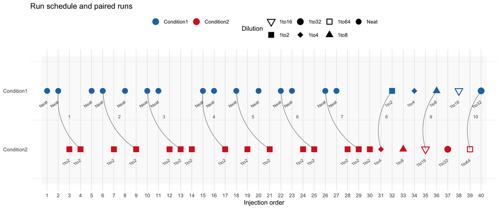

# Apply the benchmark swap

The swap is applied to the MSstats protein-level table, not to a rewritten Spectronaut report file. For the “before swap” panel, the protein-level `LogIntensities` are used as loaded. For the “after swap” panel, `swap_condition_labels()` relabels every second run within each condition for Negative proteins while leaving Positive proteins unchanged.

# Heatmap after the swap

This heatmap uses the same MSstats protein-level `LogIntensities`. Rows are proteins from the benchmark truth list and columns are Good runs only. Values are row-z-scored within protein, so the colors show relative high/low abundance across runs rather than absolute intensity. The top facet contains Positive proteins; the bottom facet contains Negative proteins after the sample-swap operation.

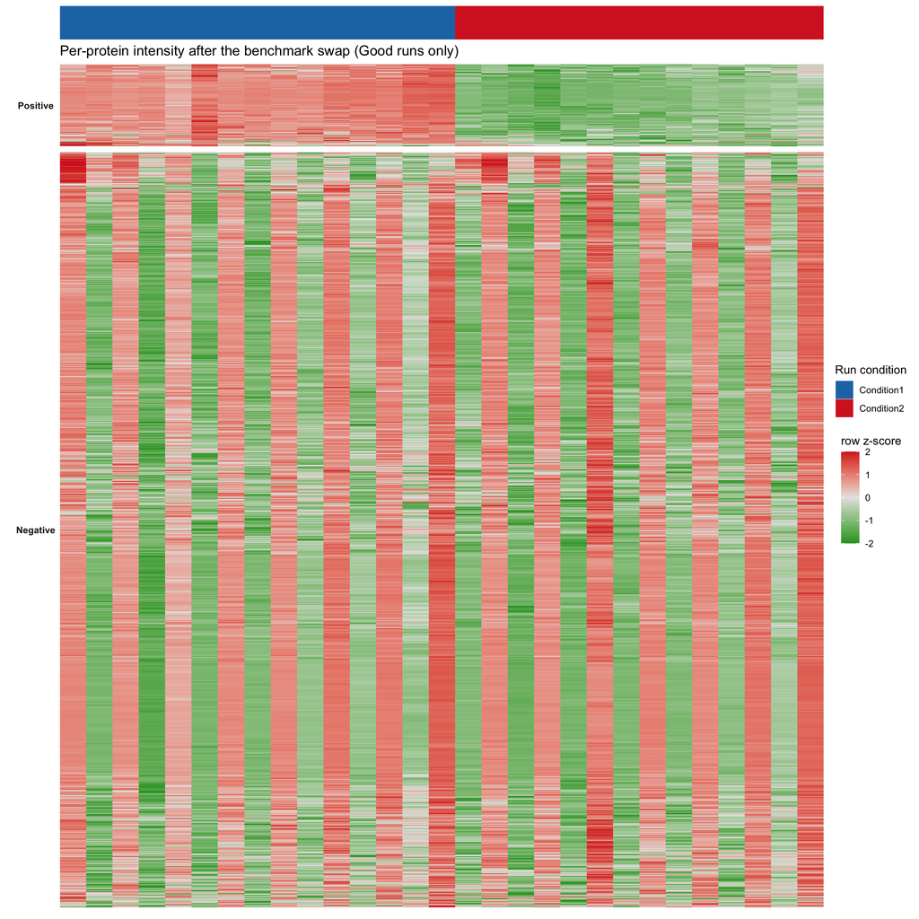

# Per-protein effect size and within-condition variance

The following panels summarize the MSstats protein-level data by protein, condition, class, and swap state. For each protein, the effect size is the mean `LogIntensities` in Condition1 minus the mean in Condition2. The pooled SD is computed from the within-condition SDs of `LogIntensities`.

## Effect size

This density plot shows the per-protein log2 fold change. Before the swap, both Positive and Negative proteins carry the CSF dilution effect. After the authors’ sample swap, Negative proteins are centered near zero while Positive proteins retain the dilution effect.

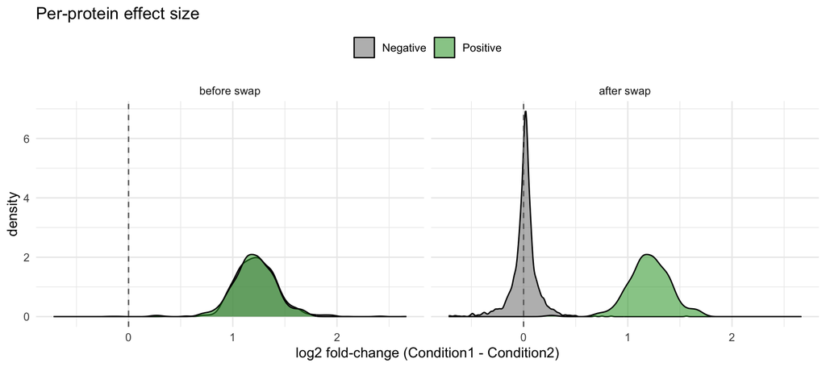

## Within-condition standard deviation

This density plot shows the pooled within-condition SD of the same MSstats protein-level `LogIntensities`. After the sample swap, Negative proteins have higher within-condition spread because each condition contains a mixture of Neat and 1:2 measurements for those proteins. Positive proteins are not swapped, so their spread remains lower.

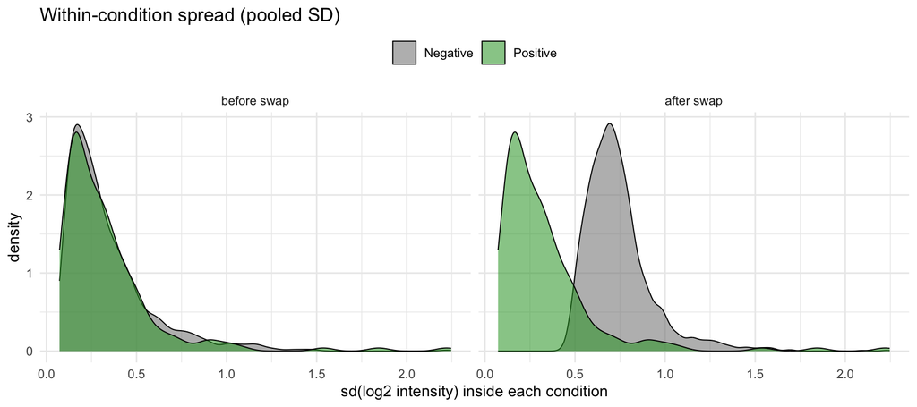

## Mean-variance relationship after swap

This scatter plot shows each protein after the swap. The x-axis is mean log2 intensity across the two conditions and the y-axis is pooled within-condition SD. The separate trends for Positive and Negative proteins are the variance moderation problem: methods using one shared mean-variance trend are asked to moderate across two label-dependent variance regimes.

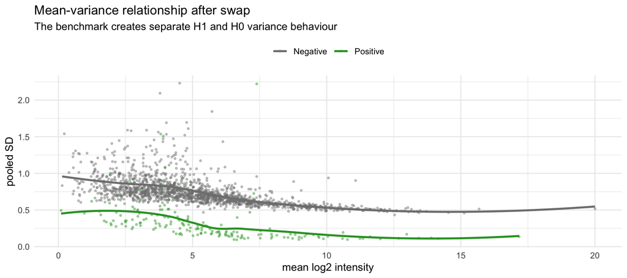